# Week 2 - Random

## Week 2 - Random Systems

Work out the first three cumulants C1, C2, and C3.

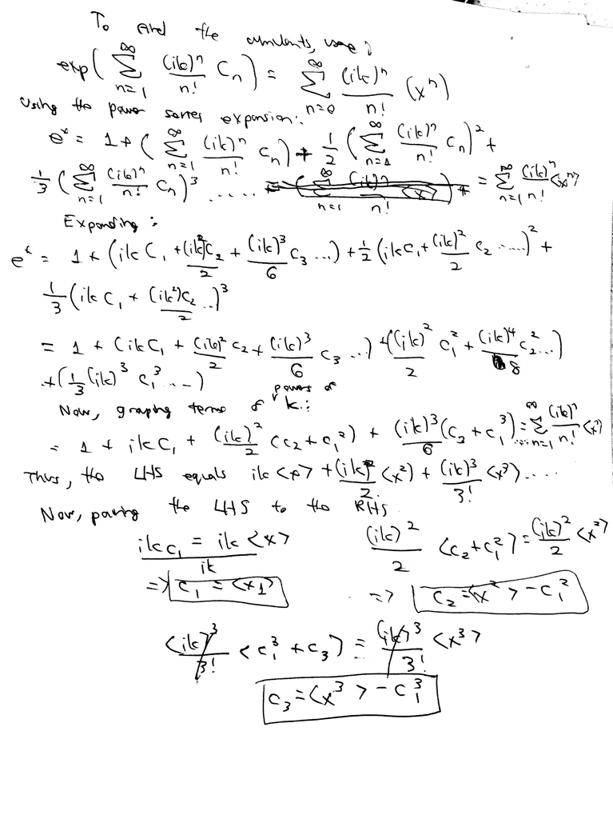

```python
from IPython.display import Image
Image(filename='files/Problem_6.1.jpg')
```

(b) Evaluate the first three cumulants for a Gaussian distribution

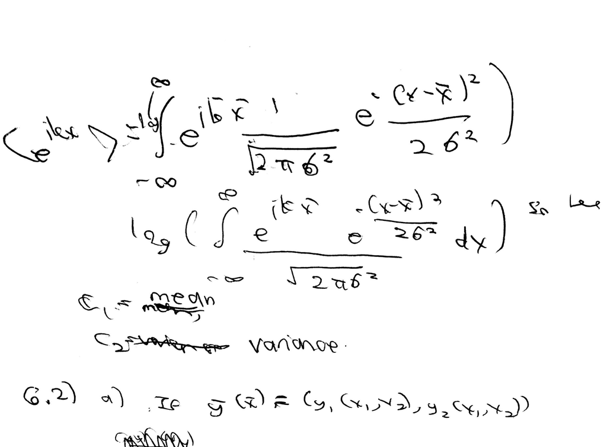

```python
Image(filename='files/Problem_6.1b.jpg')
```

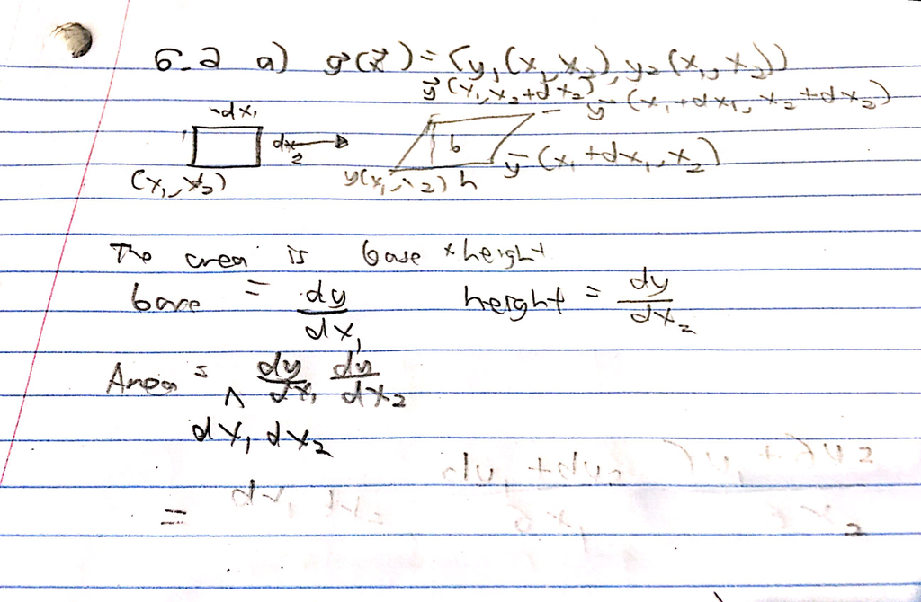

```python
Image(filename='files/wk262.jpg')
```

If p(x1, x2) is uniform, what is p(y1, y2)?

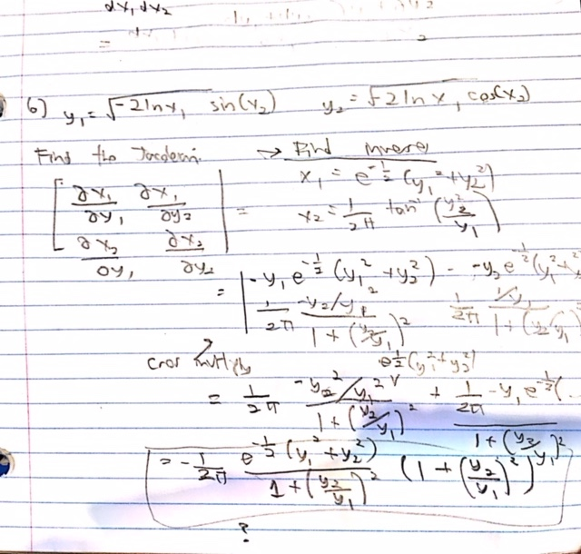

```python
Image(filename='files/wk262a.jpg')
```

(a) For an order 4 maximal LFSR write down the bit sequence.

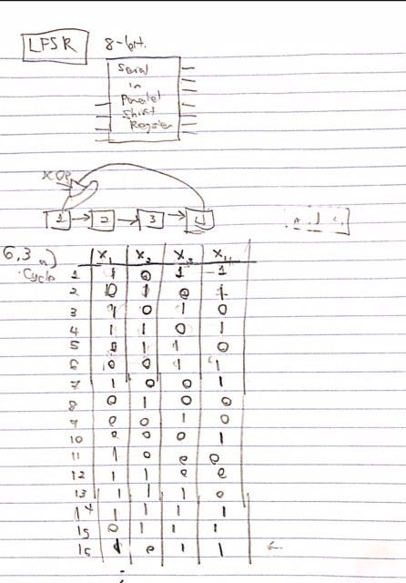

```python
Image(filename='files/wk2632.jpg')
```

(b) If an LFSR has a clock rate of 1 GHz, how long must the register be for the time between repeats to be the age of the universe (∼ 1010 years)?

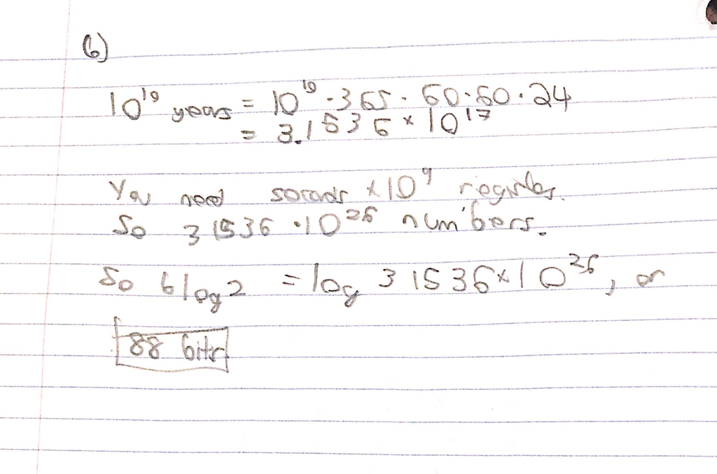

```python
## Done after class
Image(filename='files/wk263.jpg')
```

## Important Notes

Entropy is the relationship between how surprised you are and the probability of the outcome - are you more surprised the less likely something is to happen but happens? What ifyou're more surprised if something unlikely happens to two independent random variables as you are if something unlikely h appened to only one of them? This is the intuition behind entropy.

Stocahstic processes is a fancy title meaning random vairables where time is one of the variables.

Here are the written notes

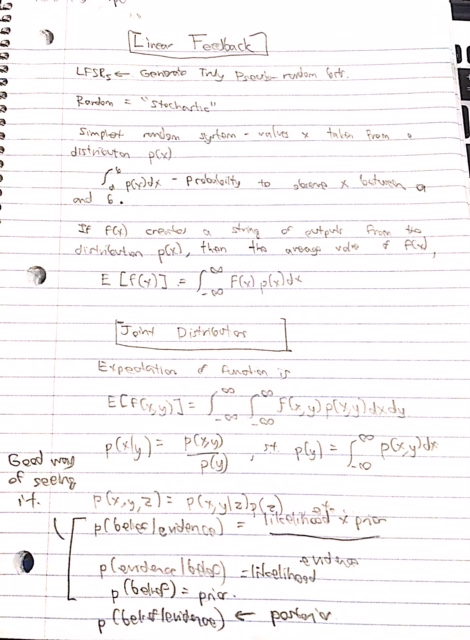

```python
from IPython.display import Image
Image(filename='files/wk2notes1.jpg')
```

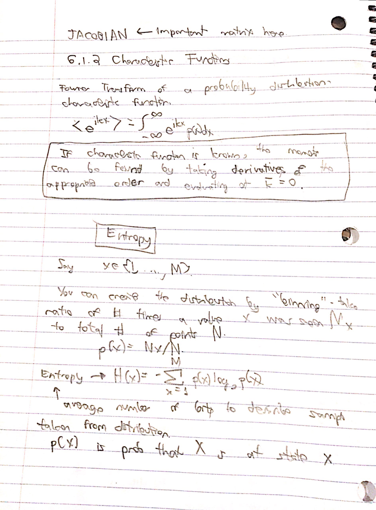

```python
Image(filename='files/wk2notes2.jpg')
```